# 04_data_wrangling1

Tobias Gerstenberg

# Pace

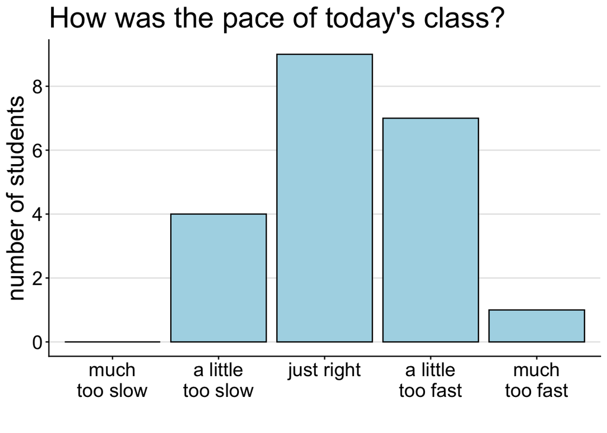

```r
df.pace = read_csv("data/How was the pace of today's class-.csv",
                   skip = 1,
                   show_col_types = FALSE) %>%
  clean_names() %>%
  mutate(response = factor(response, levels = c("much too slow", "a little too slow", "just right", "a little too fast", "much too fast"),
                           labels = c("much\ntoo slow", "a little\ntoo slow", "just right", "a little\ntoo fast", "much\ntoo fast"))) %>%
  count(response,
        .drop = F)

ggplot(data = df.pace,
       mapping = aes(x = response, y = n)) +
  geom_bar(stat = "identity", fill = "lightblue", color = "black") +
  scale_y_continuous(breaks = seq(0, 40, 2)) +
  labs(y = "number of students", x = "", title = "How was the pace of today's class?")
```

# Happiness

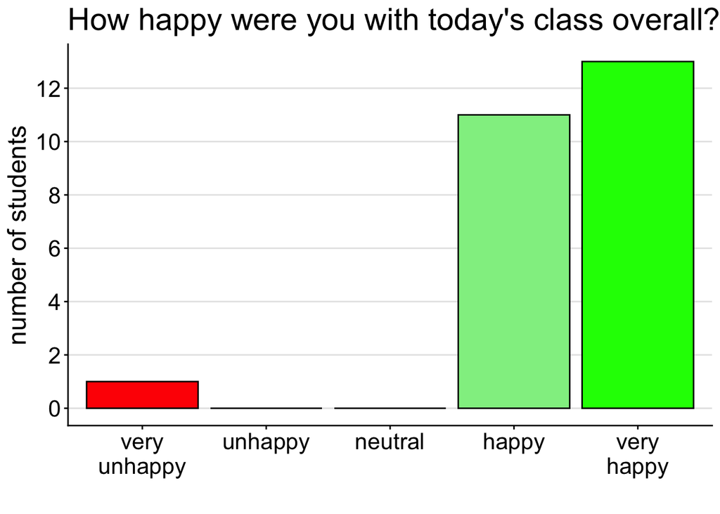

```r
df.happy = read_csv("data/How happy were you with today's class overall-.csv",
                    skip = 1,
                    show_col_types = FALSE) %>%
  clean_names() %>%
  filter(!str_detect(response, "Click")) %>% # remove response outside of the click regions
  mutate(response = as.numeric(response),
         response = factor(response, levels = 1:5,
                           labels = c("very\nunhappy", "unhappy", "neutral", "happy", "very\nhappy"))) %>%
  count(response,
        .drop = F)

ggplot(data = df.happy,
       mapping = aes(x = response, y = n)) +
  geom_bar(stat = "identity", aes(fill = response), color = "black", show.legend = F) +
  scale_fill_manual(values = c("red", "orange", "yellow", "lightgreen", "green")) +
  scale_y_continuous(breaks = seq(0, 40, 2)) +
  labs(y = "number of students", x = "", title = "How happy were you with today's class overall?") +
  theme(title = element_text(size = 18))
```

# What did you like? What can be improved?

> we went through the practice way too fast. My typing slowed down not because I was finish, but because I was still thinking by looking through the examples and figuring out what I did wrong. What would be helpful is after we go through the solution for the practice, leaving it up for a while to compare where I went wrong. For example, in practice 2, I didn’t put a space in between the names, height. I looked back at my syntax and realized I need that space. So, just slowing down to see the solution.

> Really helpful! Could you please remind us what the shortcuts are as you use them? I’m grateful to learn them but need reminders.

> I appreciate having the instructors code the examples and giving us space to try things on our own. I think group coding might also be helpful for examples that are a little more complicated. I am roughly familiar with R, but I think if I had less familiarity the groundwork information would have felt very fast because with my base it felt a little fast

[output not shown]

[output cut: 15 more lines]

# What to do next time

- go through the solutions of the practice examples more slowly